# Homework 4 Solutions

Elijah Hall, EH2794

2018-07-28

```r
require(tidyverse)
require(data.table)
require(tree)
require(ISLR)
require(MASS)
require(caret)
require(randomForest)
require(gbm)
```

```r
# plot functino for cross validation on tree digrams
plot_tree <- function(x, var1, var2) {
    temp <- data.frame(var2 = x[var2], var1 = x[var1])

    ggplot(temp, aes(x = temp[, var1], y = temp[, var2])) +
        mytheme + geom_line(col = "blue") + geom_point(col = "blue") +
        labs(title = "Inspecting Cross-Validation Results",
            x = names(temp)[1], y = names(temp)[2])
}

# find random forrest accuracy for classification
rf.accuracy <- function(x) {
    if (class(x)[1] == "randomForest.formula") {
        TP = x$confusion[1, 1]
        TN = x$confusion[2, 2]
        total <- (sum(as.matrix(x$confusion[1:2, 1:2])))
        (TP + TN)/total
    } else {
        temp <- as.matrix(x)
        TP = temp[1, 1]
        TN = temp[2, 2]
        total <- sum(temp)
        (TP + TN)/total
    }
}
```

```r
theme_update(plot.title = element_text(hjust = 0.5))

mytheme <- theme_bw() + theme(panel.border = element_blank(),
    axis.line = element_line(color = "black"), plot.background = element_blank(),
    panel.grid.major = element_blank(), panel.grid.minor = element_blank(),
    plot.title = element_text(hjust = 0.5), axis.title.x = element_text(color = "black",
        size = 10), axis.title.y = element_text(color = "black",
        size = 10))
```

```r
data("Carseats")
data("Boston")
data("OJ")
```

## Question #1 Classification Trees

## Install **tree** package and load the **ISLR** library to use *Carseats* dataset. It is a simulated data set containing sales of child car seats at 400 different stores. In this problem, we are going to investigate the variable Sales and find the mean and standard deviation of Sales.

### a. Create a binary categorical variable “High” based on the continuous Sales variable that is higher than 8 and add it to the original data frame. Type “yes” if sales are above 8, otherwise type “no”.

```r
head(Carseats)
```

```
  Sales CompPrice Income Advertising Population Price ShelveLoc Age
1  9.50       138     73          11        276   120       Bad  42
2 11.22       111     48          16        260    83      Good  65
3 10.06       113     35          10        269    80    Medium  59
4  7.40       117    100           4        466    97    Medium  55
5  4.15       141     64           3        340   128       Bad  38
6 10.81       124    113          13        501    72       Bad  78
  Education Urban  US
1        17   Yes Yes
2        10   Yes Yes
3        12   Yes Yes
4        14   Yes Yes
5        13   Yes  No
6        16    No Yes
```

```r
# mean(Carseats$Sales) sd(Carseats$Sales)

Carseats <- Carseats %>% mutate(High = factor(ifelse(Carseats$Sales >
    8, "yes", "no")))
```

### b. Using an already built function called *tree*, construct the decision tree predicting **High** from all other variables in the dataset defining splits based upon the Gini coefficient. How many terminal nodes are there in your initial tree?

```r
set.seed(0)
D.tree.1 <- tree(formula = High ~ ., data = Carseats[, -1],
    method = "gini")
summary(D.tree.1)$misclass[1]
```

```
[1] 36
```

There are 27 terminal nodes and the overall tree has a missclassification rate of 0.09.

3. Split the data into a training and test set with an 70%-30% split, respectively. Use `set.seed(0)` so your results will be reproducible.

```r
set.seed(0)
train <- sample(x = 1:nrow(Carseats), size = round(0.7 *
    nrow(Carseats)))
```

4. Fit and predict the High variable for observations that are within your test set using the *tree* function on training and test sets you made in step c. Report the accuracy of the prediction using the confusion Matrix.

```r
set.seed(0)
D.tree.2 <- tree(formula = High ~ ., data = Carseats[train,
    -1], method = "gini")

D.tree.2.pred <- predict(object = D.tree.2, newdata = Carseats[-train,
    ])[, 2]
D.tree.2.pred[D.tree.2.pred >= 0.5] <- "yes"
D.tree.2.pred[D.tree.2.pred < 0.5] <- "no"

D.tree.2.cmat <- confusionMatrix(factor(D.tree.2.pred),
    factor(Carseats$High[-train]), positive = "yes", dnn = c("Prediction",
        "Reference"))
D.tree.2.cmat
```

```
Confusion Matrix and Statistics

          Reference
Prediction no yes
       no  60  12
       yes  6  42

               Accuracy : 0.85
                 95% CI : (0.7733, 0.9086)
    No Information Rate : 0.55
    P-Value [Acc > NIR] : 2.59e-12

                  Kappa : 0.6939
 Mcnemar's Test P-Value : 0.2386

            Sensitivity : 0.7778
            Specificity : 0.9091
         Pos Pred Value : 0.8750
         Neg Pred Value : 0.8333
             Prevalence : 0.4500
         Detection Rate : 0.3500
   Detection Prevalence : 0.4000
      Balanced Accuracy : 0.8434

       'Positive' Class : yes
```

The accuracy of this model is 0.85. The model is better than a random guess, however it doesn’t seem to be very good as is.

5. Implement cross-validation using *cv.tree* and, thus, cost-complexity pruning to determine how far back to *prune your tree* (`FUN=prune.misclass`). Use `set.seed(0)`.

```r
set.seed(0)
D.tree.2.cv <- cv.tree(object = D.tree.2, FUN = prune.misclass)
D.tree.2.cv
```

```
$size
 [1] 25 18 16 12 10  8  4  3  2  1

$dev
 [1]  85  85  85  86  83  83  78  82  91 112

$k
 [1]  -Inf  0.00  1.00  1.50  2.00  3.50  4.25  5.00 12.00 28.00

$method
[1] "misclass"

attr(,"class")
[1] "prune"         "tree.sequence"
```

6. When you inspect the *cv.tree*, the size indicates the number of terminal nodes, the deviance is the criterion we specify (the misclassification rate in this case), and *k* is analogous to the cost complexity tuning parameter alpha. Method indicates the specified criterion. Visualize the results from f across various numbers of terminal nodes/values for alpha.

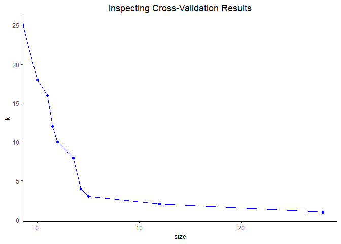

```r
plot_tree(D.tree.2.cv, "k", "size")
```

As the number of nodes increase the cost of complexity approaches -Infinity.

7. Explain the appropriate number of terminal nodes to prune the tree. Prune your tree using *prune.misclass*.

```r
# calculate best number of nodes to prune at that
# minimizes dev
best <- round(mean(D.tree.2.cv$size[which(D.tree.2.cv$dev ==
    min(D.tree.2.cv$dev))]))

# prune tree
D.tree.2.prune <- prune.misclass(D.tree.2, best = best)
```

The best number of nodes to prune at is 4, since it minimizes the deviance or missclassification rate.

8. Predict the **High** Sales variable for observations that are within your test set using this pruned tree. Report the accuracy of your predictions using the confusion Matrix.

```r
D.tree.2.prune.pred <- predict(D.tree.2.prune, newdata = Carseats[-train,
    -1])[, 2]
D.tree.2.prune.pred[D.tree.2.prune.pred >= 0.5] <- "yes"
D.tree.2.prune.pred[D.tree.2.prune.pred < 0.5] <- "no"
D.tree.2.prune.cmat <- confusionMatrix(factor(D.tree.2.prune.pred),
    factor(Carseats$High[-train]), positive = "yes", dnn = c("Prediction",
        "Reference"))
D.tree.2.prune.cmat
```

```
Confusion Matrix and Statistics

          Reference
Prediction no yes
       no  53  21
       yes 13  33

               Accuracy : 0.7167
                 95% CI : (0.6272, 0.7951)
    No Information Rate : 0.55
    P-Value [Acc > NIR] : 0.000132

                  Kappa : 0.4198
 Mcnemar's Test P-Value : 0.229949

            Sensitivity : 0.6111
            Specificity : 0.8030
         Pos Pred Value : 0.7174
         Neg Pred Value : 0.7162
             Prevalence : 0.4500
         Detection Rate : 0.2750
   Detection Prevalence : 0.3833
      Balanced Accuracy : 0.7071

       'Positive' Class : yes
```

The accuracy of this model is 0.717. The model performs worse than the previous.

## Question #2 Regression Trees

Load the library **MASS** and *Boston* dataset that contains the inspection of housing values in the suburbans of Boston. Inspect the dataset before doing follwing steps.

```r
glimpse(Boston)
```

```
Observations: 506
Variables: 14
$ crim    <dbl> 0.00632, 0.02731, 0.02729, 0.03237, 0.06905, 0.02985, ...
$ zn      <dbl> 18.0, 0.0, 0.0, 0.0, 0.0, 0.0, 12.5, 12.5, 12.5, 12.5,...
$ indus   <dbl> 2.31, 7.07, 7.07, 2.18, 2.18, 2.18, 7.87, 7.87, 7.87, ...
$ chas    <int> 0, 0, 0, 0, 0, 0, 0, 0, 0, 0, 0, 0, 0, 0, 0, 0, 0, 0, ...
$ nox     <dbl> 0.538, 0.469, 0.469, 0.458, 0.458, 0.458, 0.524, 0.524...
$ rm      <dbl> 6.575, 6.421, 7.185, 6.998, 7.147, 6.430, 6.012, 6.172...
$ age     <dbl> 65.2, 78.9, 61.1, 45.8, 54.2, 58.7, 66.6, 96.1, 100.0,...
$ dis     <dbl> 4.0900, 4.9671, 4.9671, 6.0622, 6.0622, 6.0622, 5.5605...
$ rad     <int> 1, 2, 2, 3, 3, 3, 5, 5, 5, 5, 5, 5, 5, 4, 4, 4, 4, 4, ...
$ tax     <dbl> 296, 242, 242, 222, 222, 222, 311, 311, 311, 311, 311,...
$ ptratio <dbl> 15.3, 17.8, 17.8, 18.7, 18.7, 18.7, 15.2, 15.2, 15.2, ...
$ black   <dbl> 396.90, 396.90, 392.83, 394.63, 396.90, 394.12, 395.60...
$ lstat   <dbl> 4.98, 9.14, 4.03, 2.94, 5.33, 5.21, 12.43, 19.15, 29.9...
$ medv    <dbl> 24.0, 21.6, 34.7, 33.4, 36.2, 28.7, 22.9, 27.1, 16.5, ...
```

```r
summary(Boston)
```

```
      crim                zn             indus            chas
 Min.   : 0.00632   Min.   :  0.00   Min.   : 0.46   Min.   :0.00000
 1st Qu.: 0.08204   1st Qu.:  0.00   1st Qu.: 5.19   1st Qu.:0.00000
 Median : 0.25651   Median :  0.00   Median : 9.69   Median :0.00000
 Mean   : 3.61352   Mean   : 11.36   Mean   :11.14   Mean   :0.06917
 3rd Qu.: 3.67708   3rd Qu.: 12.50   3rd Qu.:18.10   3rd Qu.:0.00000
 Max.   :88.97620   Max.   :100.00   Max.   :27.74   Max.   :1.00000
      nox               rm             age              dis
 Min.   :0.3850   Min.   :3.561   Min.   :  2.90   Min.   : 1.130
 1st Qu.:0.4490   1st Qu.:5.886   1st Qu.: 45.02   1st Qu.: 2.100
 Median :0.5380   Median :6.208   Median : 77.50   Median : 3.207
 Mean   :0.5547   Mean   :6.285   Mean   : 68.57   Mean   : 3.795
 3rd Qu.:0.6240   3rd Qu.:6.623   3rd Qu.: 94.08   3rd Qu.: 5.188
 Max.   :0.8710   Max.   :8.780   Max.   :100.00   Max.   :12.127
      rad              tax           ptratio          black
 Min.   : 1.000   Min.   :187.0   Min.   :12.60   Min.   :  0.32
 1st Qu.: 4.000   1st Qu.:279.0   1st Qu.:17.40   1st Qu.:375.38
 Median : 5.000   Median :330.0   Median :19.05   Median :391.44
 Mean   : 9.549   Mean   :408.2   Mean   :18.46   Mean   :356.67
 3rd Qu.:24.000   3rd Qu.:666.0   3rd Qu.:20.20   3rd Qu.:396.23
 Max.   :24.000   Max.   :711.0   Max.   :22.00   Max.   :396.90
     lstat            medv
 Min.   : 1.73   Min.   : 5.00
 1st Qu.: 6.95   1st Qu.:17.02
 Median :11.36   Median :21.20
 Mean   :12.65   Mean   :22.53
 3rd Qu.:16.95   3rd Qu.:25.00
 Max.   :37.97   Max.   :50.00
```

### Variable Descriptions

- **CRIM** - per capita crime rate by town
- **ZN** - proportion of residential land zoned for lots over 25,000 sq.ft.
- **INDUS** - proportion of non-retail business acres per town.
- **CHAS** - Charles River dummy variable (1 if tract bounds river; 0 otherwise)
- **NOX** - nitric oxides concentration (parts per 10 million)
- **RM** - average number of rooms per dwelling
- **AGE** - proportion of owner-occupied units built prior to 1940
- **DIS** - weighted distances to five Boston employment centres
- **RAD** - index of accessibility to radial highways
- **TAX** - full-value property-tax rate per $10,000
- **PTRATIO** - pupil-teacher ratio by town
- **B** - 1000(Bk - 0.63)^2 where Bk is the proportion of blacks by town
- **LSTAT** - % lower status of the population
- **MEDV** - Median value of owner-occupied homes in $1000’s
- Note Variable **MEDV** seems to be censored at 50.00 (corresponding to a median price of 50,000) Censoring is suggested by the fact that the highest median price of exactly 50,000 is reported in 16 cases, while 15 cases have prices between 40,000 and 50,000, with prices rounded to the nearest hundred. Harrison and Rubinfeld do not mention any censoring.
1. Split the data by 70%-30%.

```r
train <- sample(x = 1:nrow(Boston), size = round(0.7 * nrow(Boston)))
```

2. Train the tree to predict the median value of owner-occupied homes (in $1 K).

```r
D.tree.boston = tree(medv ~ ., Boston, subset = train)
summary(D.tree.boston)
```

```
Regression tree:
tree(formula = medv ~ ., data = Boston, subset = train)
Variables actually used in tree construction:
[1] "rm"      "lstat"   "dis"     "tax"     "crim"    "ptratio"
Number of terminal nodes:  12
Residual mean deviance:  11.98 = 4098 / 342
Distribution of residuals:
    Min.  1st Qu.   Median     Mean  3rd Qu.     Max.
-16.7400  -1.9380  -0.2297   0.0000   1.8440  20.8700
```

3. Perform the cross-validation and determine the prune number of tree. **Note:** Use the default function to do the pruning.

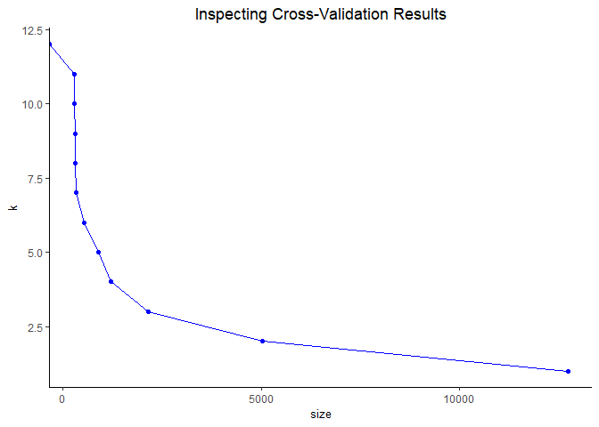

```r
cv.D.tree.boston <- cv.tree(D.tree.boston)

plot_tree(cv.D.tree.boston, "k", "size")
```

```r
best <- cv.D.tree.boston$size[which(cv.D.tree.boston$dev ==
    min(cv.D.tree.boston$dev))]

prune.boston <- prune.tree(D.tree.boston, best = 8)
summary(prune.boston)
```

```
Regression tree:
snip.tree(tree = D.tree.boston, nodes = c(16L, 7L, 9L, 11L))
Variables actually used in tree construction:
[1] "rm"    "lstat" "crim"
Number of terminal nodes:  8
Residual mean deviance:  15.29 = 5289 / 346
Distribution of residuals:
    Min.  1st Qu.   Median     Mean  3rd Qu.     Max.
-23.2800  -2.0560  -0.1764   0.0000   1.6700  26.4700
```

The default for the pruned tree is returning the full tree. Therefore I chose best= 8 to evaluate a difference on the following questions.

4. Calculate and assess the MSE value of owner-occupied homes (in $1 K) of the test data on the overall tree.

```r
boston_pred <- predict(D.tree.boston, newdata = Boston[-train,
    ])
boston.test = Boston[-train, "medv"]

# calculate MSE
full.MSE <- mean((boston_pred - boston.test)^2)
```

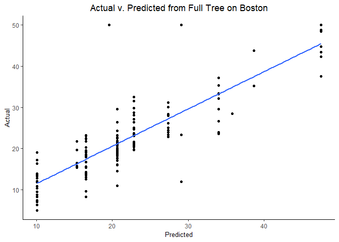

```r
# compare vlaues
ggplot(data.frame(boston_pred, boston.test), aes(x = boston_pred,
    y = boston.test)) + mytheme + geom_point() + geom_smooth(method = "lm",
    se = F) + labs(title = "Actual v. Predicted from Full Tree on Boston",
    x = "Predicted", y = "Actual")
```

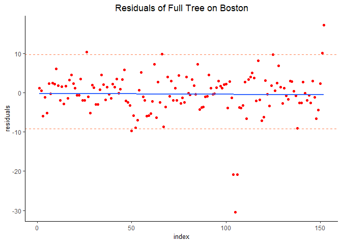

```r
# plot residuals
resid_df <- data.frame(index = 1:length(boston_pred), residuals = (boston_pred -
    boston.test))
ggplot(resid_df, aes(x = index, y = residuals)) + mytheme +
    geom_point(col = "red") + geom_smooth(method = "lm",
    se = F) + geom_hline(yintercept = quantile(resid_df$residuals,
    0.975, na.rm = T), lty = 2, col = "coral") + geom_hline(yintercept = quantile(resid_df$residuals,
    0.025, na.rm = T), lty = 2, col = "coral") + labs(title = "Residuals of Full Tree on Boston")
```

5. Calculate the MSE of the test data on the pruned tree.

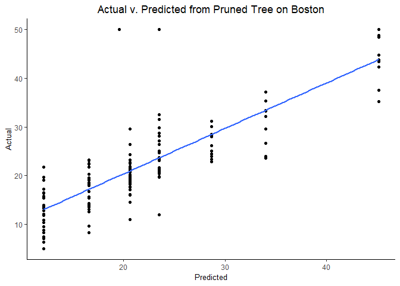

```r
pruned_boston_pred <- predict(prune.boston, newdata = Boston[-train,
    ])

# compare vlaues
ggplot(data.frame(pruned_boston_pred, boston.test), aes(x = pruned_boston_pred,
    y = boston.test)) + mytheme + geom_point() + geom_smooth(method = "lm",
    se = F) + labs(title = "Actual v. Predicted from Pruned Tree on Boston",
    x = "Predicted", y = "Actual")
```

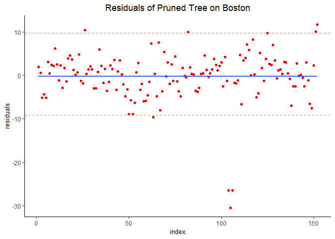

```r
# plot residuals
resid_df <- data.frame(index = 1:length(pruned_boston_pred),
    residuals = (pruned_boston_pred - boston.test))
ggplot(resid_df, aes(x = index, y = residuals)) + mytheme +
    geom_point(col = "red") + geom_smooth(method = "lm",
    se = F) + geom_hline(yintercept = quantile(resid_df$residuals,
    0.975, na.rm = T), lty = 2, col = "coral") + geom_hline(yintercept = quantile(resid_df$residuals,
    0.025, na.rm = T), lty = 2, col = "coral") + labs(title = "Residuals of Pruned Tree on Boston")
```

```r
# calculate MSE
pruned.MSE <- mean((pruned_boston_pred - boston.test)^2)
```

## Question #3 Bagging & Random Forests

Load the *OJ* dataset from the **ISLR** library into your workspace. The data contains 1,070 purchases where custromer either purchase Citrus Hill or Minute Maid orange juice. A number of characteristics of the customer and product are recorded. Install the package called **randomForest**.

### Variable Descriptions

**Purchase** - A factor with levels CH and MM indicating whether the customer purchased Citrus Hill or Minute Maid Orange Juice **WeekofPurchase** - Week of purchase **StoreID** - Store ID **PriceCH** - Price charged for CH **PriceMM** - Price charged for MM **DiscCH** - Discount offered for CH **DiscMM** - Discount offered for MM **SpecialCH** - Indicator of special on CH **SpecialMM** - Indicator of special on MM **LoyalCH** - Customer brand loyalty for CH **SalePriceMM** - Sale price for MM **SalePriceCH** - Sale price for CH **PriceDiff** - Sale price of MM less sale price of CH **Store7** - A factor with levels No and Yes indicating whether the sale is at Store 7 **PctDiscMM** - Percentage discount for MM **PctDiscCH** - Percentage discount for CH **ListPriceDiff** - List price of MM less list price of CH **STORE** - Which of 5 possible stores the sale occured at

### 1. Split the data into a training and test set with an 80%-20% split, respectively.

```r
set.seed(0)
train <- sample(x = 1:nrow(OJ), size = round(0.8 * nrow(OJ)))
```

### 2. Construct an initial random forest predicting the correct brand purchase from all other variables in the training dataset using the default setting; this will create 500 trees. (use `set.seed(0)`).

```r
set.seed(0)
rf.mod1 <- randomForest(Purchase ~ ., data = OJ, mtry = 17,
    subset = train)
sum_rf.mod1 <- summary(rf.mod1)
```

### 3. What is the accuracy of this initial random forest on the training set? What about on the test set?

```r
train.acc <- rf.accuracy(rf.mod1)

test.acc <- rf.accuracy(randomForest(Purchase ~ ., data = OJ,
    mtry = 17, subset = -train))
```

The accuracy of the initial model is 0.789 on the training set and 0.785 on the test set.

### 4. Which variable is aiding the most in classifying the orange juice purchases? Use function `importance()`.

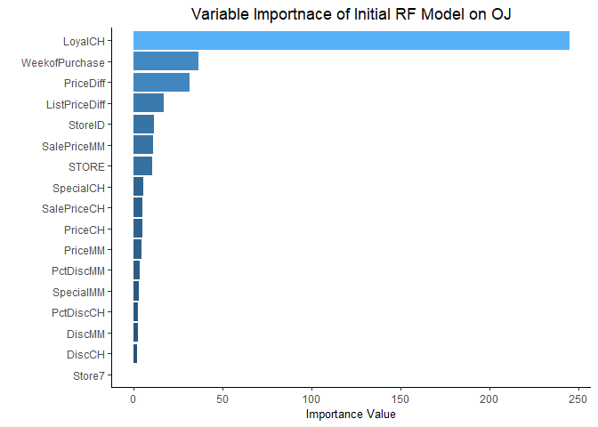

```r
imp_df <- importance(rf.mod1) %>% as.data.frame()
imp_df <- data.frame(importance = imp_df[, 1], Name = row.names(imp_df))
imp_df <- imp_df %>% arrange(importance)
imp_df$Name <- factor(imp_df$Name, levels = imp_df$Name)
ggplot(imp_df, aes(y = importance, x = Name, fill = log(importance))) +
    mytheme + geom_bar(stat = "identity") + theme(legend.position = "none") +
    coord_flip() + labs(title = "Variable Importnace of Initial RF Model on OJ",
    x = "", y = "Importance Value")
```

### 5. Vary the number of variables considered as candidates at each node split in the random forest procedure (from one to all predictors).Record the out-of-bag error rates for each of these random forests on the training set. (Use `set.seed(0)` so your results will be reproducible.) (Hint: You will want to record the error rate). You can follow the following algorithm for this problem.

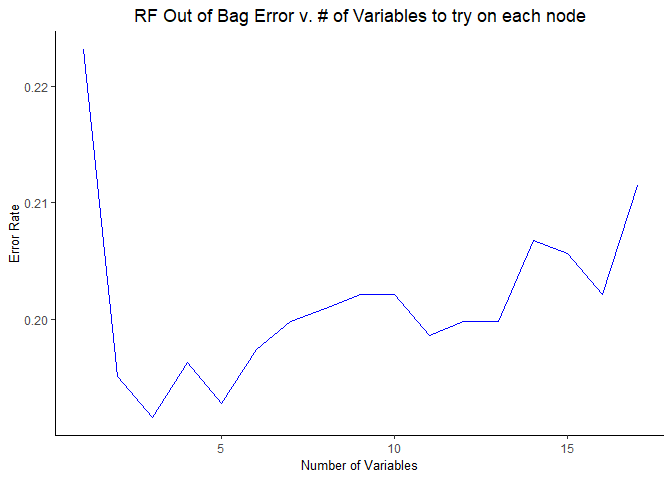

```r
set.seed(0)
rf.mod1 <- randomForest(Purchase ~ ., data = OJ, mtry = 17,
    subset = train)
sum_rf.mod1 <- summary(rf.mod1)

n_var <- seq(17)

rf.mod.oob.er <- c()
for (i in n_var) {
    set.seed(0)
    temp.rf.mod <- randomForest(Purchase ~ ., data = OJ,
        mtry = i, subset = train)
    rf.mod.oob.er[i] <- tail(temp.rf.mod$err.rate, 1)[1,
        1]
}

ggplot(data.frame(n_var = n_var, error = rf.mod.oob.er),
    aes(x = n_var, y = error)) + mytheme + geom_line(col = "blue") +
    labs(title = "RF Out of Bag Error v. # of Variables to try on each node",
        x = "Number of Variables", y = "Error Rate")
```

```r
n_var[rf.mod.oob.er == min(rf.mod.oob.er)]
```

```
[1] 3
```

## Question #4 Boosting

Continue using the OJ dataset and the training/test sets you already loaded into your workspace. Install a package **gbm**.

1. In order to boost with classification trees, we need to do a bit of data munging to transform the response variable. You may use the following lines of code to produce the copies of your dataset OJ.train.indicator and OJ.test.indicator that have a transformed response variable. (You must replace OJ.trainand OJ.test with whatever names you used in your own code.)

```r
# transform the response variable
OJ.train.indicator = OJ[train, ]
OJ.test.indicator = OJ[-train, ]
OJ.train.indicator$Purchase = as.vector(OJ$Purchase[train],
    mode = "numeric") - 1
OJ.test.indicator$Purchase = as.vector(OJ$Purchase[-train],
    mode = "numeric") - 1
```

2. Construct an initial boosted model on the training set that uses all of the following settings at once: Use set.seed(0).
   1. The Bernoulli distribution.
   2. 10,000 trees.
   3. An interaction depth of 4.
   4. A shrinkage parameter of 0.001.

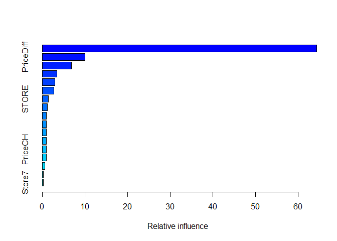

```
                          var    rel.inf
LoyalCH               LoyalCH 64.3206449
PriceDiff           PriceDiff  9.9815275
WeekofPurchase WeekofPurchase  6.8450853
ListPriceDiff   ListPriceDiff  3.4122500
StoreID               StoreID  2.9435276
SalePriceMM       SalePriceMM  2.7427449
STORE                   STORE  1.3966582
SalePriceCH       SalePriceCH  1.2336645
PriceMM               PriceMM  1.0329644
SpecialCH           SpecialCH  1.0146469
DiscMM                 DiscMM  0.9996735
SpecialMM           SpecialMM  0.9973203
PriceCH               PriceCH  0.9902113
DiscCH                 DiscCH  0.9473162
PctDiscMM           PctDiscMM  0.6502663
PctDiscCH           PctDiscCH  0.2658368
Store7                 Store7  0.2256614
```

```r
set.seed(0)
boost.oj <- gbm(Purchase ~ ., data = OJ.train.indicator,
    distribution = "bernoulli", n.trees = 10000, interaction.depth = 4,
    shrinkage = 0.001)
summary(boost.oj)
```

3. Predict your test set observations using the initial boosted model across up to 10,000 trees, considering groups of 100 trees at a time. (Hint: Use `type = "response"`) and round your ultimate predictions.)

```r
predmat <- matrix(NA, nrow = 214, ncol = 100)
set.seed(0)
for (i in 1:100) {
    predmat[, i] <- round(predict(boost.oj, newdata = OJ.test.indicator,
        n.trees = i * 100, type = "response"))
}
```

4. Calculate and store the accuracy for each of the 100 models considered in part 3. What is the minimum number of trees required to reach the maximum accuracy?

```r
n_tree = seq(1:100) * 100
acc_ntree <- c()
for (i in 1:ncol(predmat)) {
    acc_ntree[i] <- rf.accuracy(table(factor(OJ.test.indicator$Purchase,
        levels = c(0, 1)), factor(predmat[, i], levels = c(0,
        1))))
}

# minimum number of trees needed to reach maximum
# accuracy
n_tree_min <- min(n_tree[acc_ntree == max(acc_ntree)])
```

The minimum number of trees needed to reach the maximum accuracy of this model is 2100 trees. It shoul dbe noted as you will see below that the added benifit is marginal to the added complexity needed to reach this level of accuracy. If complexity costs are high then consideration should be made to use less trees.

5. Plot the accuracies found in part 4 against the number of trees. Add to the plot:

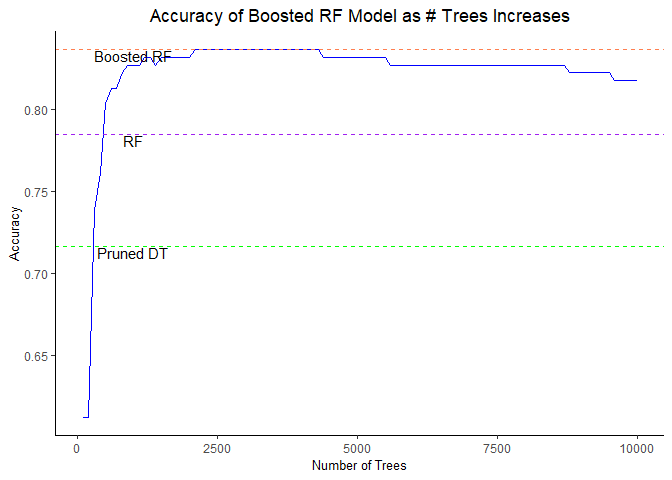

```r
ggplot(data.frame(n_tree = n_tree, accuracy = acc_ntree),
    aes(x = n_tree, y = accuracy)) + mytheme + geom_line(col = "blue") +
    geom_hline(yintercept = max(acc_ntree), lty = 2, col = "coral") +
    annotate(geom = "text", x = 1000, y = max(acc_ntree),
        label = paste("Boosted RF"), vjust = 1) + geom_hline(yintercept = test.acc,
    lty = 2, col = "purple") + annotate(geom = "text", x = 1000,
    y = test.acc, label = paste("RF"), vjust = 1) + geom_hline(yintercept = D.tree.2.prune.cmat$overall[1],
    lty = 2, col = "green") + annotate(geom = "text", x = 1000,
    y = D.tree.2.prune.cmat$overall[1], label = paste("Pruned DT"),
    vjust = 1) + labs(title = "Accuracy of Boosted RF Model as # Trees Increases",
    x = "Number of Trees", y = "Accuracy")
```